# chapter5probs_nudibranchs

```r
knitr::opts_chunk$set(echo = TRUE)

library(tidyverse)
library(RColorBrewer)

# This book has an R package!

library(primer) #install.packages('primer')
```

# Chapter 5: Lotka-Volterra Interspecific Competition

## 5.1. Basics

Let $\alpha_{11} = \alpha_{22} = 0.1, \alpha_{12} = 0.05, \alpha_{21} = 0.01$.

1. Determine $N_1^∗, N_2^∗, K_1, K_2$.
2. Draw (by hand, or in R) the ZNGIs (zero net growth isoclines); include arrows that indicate trajectories, and label the axes.
3. Select other values for the $\alpha$ and repeat (a) and (b); swap your answers with a friend, and check each other’s work.
4. Start with equilibria for competing species, and show algebraically that when interspecific competition is nonexistent, species reach their carrying capacities.

#### Sean’s attempts

1. Determine $N_1^*, N_2^*, K_1, K_2$.

First, the models for Lotka-Volterra Interspecific Competition are:
$$N_{1,t+1} = N_{1,t} + r_{1,d} N_{1,t} (1 - \alpha_{11} N_{1,t} - \alpha_{21} N_{2,t})$$
$$N_{2,t+1} = N_{2,t} + r_{2,d} N_{2,t} (1 - \alpha_{21} N_{1,t} - \alpha_{22} N_{2,t})$$

We can determine $K_1$ and $K_2$ by using $K_i = \frac{1}{\alpha_{ii}}$

```r
a_11 <- a_22 <- 0.1
a_12 <- 0.05
a_21 <- 0.01

# Could also make a matrix (I think):

alphas_prob_1 <- matrix(c(0.1, 0.05, 0.01, 0.1), ncol = 2, byrow = TRUE) # But would we only do this if we were going to insert this matrix into a model that considers which alpha is which, right?

# Options (I think):
# Create a function
# Write expressions and then evaluate them # Why would we do this here?
# Just write it out

K_1 = (1 / a_11) # 10
K_2 = (1 / a_22) # 10
```

We can find $N_1^*$ and $N_2^*$ by writing the Lotka-Volterra interspecific competition models at equilibrium, and then subsitting one (either $N_1^*$ or $N_2^*$ into the other. So…
$$\frac{dN_1}{dt} = 0 = r_{1,d} N_{1,t} (1 - \alpha_{11} N_{1,t} - \alpha_{21} N_{2,t})$$
$$\frac{dN_2}{dt} = 0 = r_{2,d} N_{2,t} (1 - \alpha_{21} N_{1,t} - \alpha_{22} N_{2,t})$$
Then, (for some reason I couldn’t re-write these in the form of $N_i^*$ in LaTex, so see code below)

```r
N_1_star <- (a_22 - a_12) / (a_11 * a_22 - a_12 * a_21) # 5.26

N_2_star <- (a_11 - a_21) / (a_22 * a_11 - a_12 * a_21) # 9.47
```

2. Draw the ZNGIs (zero net growth isoclines); include arrows that indicate trajectories, and label the axes.

```r
# Need to graph equations of lines in the tidyverse (???)

# You could make a small increment sequence based on a model, and then used predict to graph it?
```

3. Select other values for the $\alpha$ and repeat (a) and (b); swap your answers with a friend, and check each other’s work.
4. Start with equilibria for competing species, and show algebraically that when interspecific competition is nonexistent, species reach their carrying capacities.

#### Jessica’s attempt

$\alpha_{11} = \alpha_{22} = 0.1$  
$\alpha_{12} = 0.05$  
$\alpha_{21} = 0.01$

##### A. Determine $N_1^∗, N_2^∗, K_1, K_2$

$$N^*_1=\frac{\alpha_{22}-\alpha_{12}}{\alpha_{11}\alpha_{22}-\alpha_{12}\alpha_{21}}$$

```r
alphs<-matrix(c(0.1,0.05,0.01,0.1),ncol=2)

n1eq<-(alphs[2,2]-alphs[1,2])/((alphs[1,1]*alphs[2,2])-(alphs[1,2]*alphs[2,1]))

n2eq<-(alphs[1,1]-alphs[2,1])/((alphs[1,1]*alphs[2,2])-(alphs[1,2]*alphs[2,1]))
```

$$K_i=\frac{1}{\alpha_{i,i}}$$

```r
k1<-1/(alphs[1,1])

k2<-1/(alphs[2,2])
```

…and $K_1=$ 10 and $K_2=$ 10

##### B. Draw the ZNGIs (zero net growth isoclines); include arrows that indicate trajectories, and label the axes.

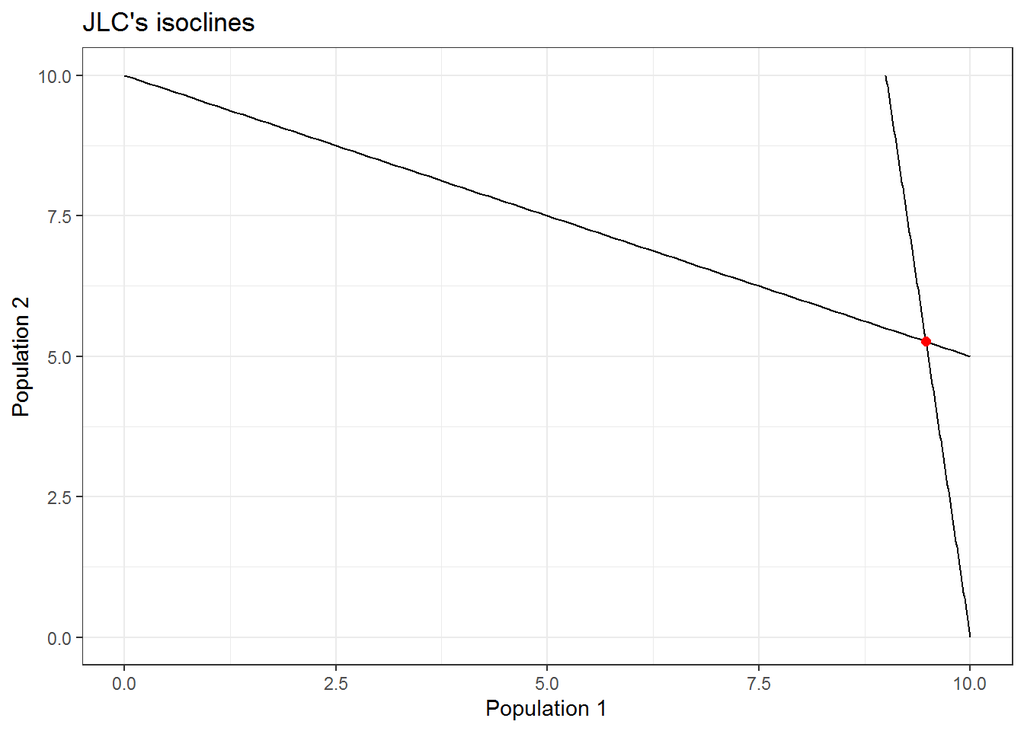

```r
n2vec=seq(0,k2,by=0.1)

iso1<-data.frame(n2=n2vec)%>%
  mutate(n1iso=(1/alphs[1,1])-(alphs[1,2]/alphs[1,1])*n2)


n1vec=seq(0,k1,by=0.1)
iso2<-data.frame(n1=n1vec)%>%
  mutate(n2iso=(1/alphs[2,2])-(alphs[2,1]/alphs[2,2])*n1)

ggplot(iso1,aes(n1iso,n2))+
  geom_line()+
  geom_line(data=iso2,aes(n1,n2iso))+
  geom_point(x=n1eq,y=n2eq,color="red",size=2)+
  labs(x="Population 1",y="Population 2",title="JLC's isoclines")+
  theme_bw()
```